# LAB_2-Copy1

```python
import numpy as np
import matplotlib.pyplot as plt
import scipy.stats as stats
from scipy.stats import poisson
```

To set up the problem, assume in 1 day the average cosmic-ray background is some number X (pick someting btwn 0.5 and 10, with different values for you and your lab partner); and the average number of gamma-rays emitted by your hypothetical source is Y (pick something larger than X).

**A. Evolution of probability distribution over 9 days.**

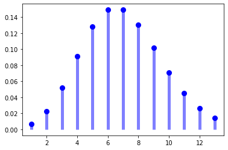

```python
fig, ax = plt.subplots(1, 1)
mu = 7
mean, var, skew, kurt = poisson.stats(mu, moments='mvsk')
x = np.arange(poisson.ppf(0.001, mu),
              poisson.ppf(0.99, mu))
p=poisson.pmf(x, mu)
ax.plot(x, p, 'bo', ms=8, label='poisson pmf')
ax.vlines(x, 0, poisson.pmf(x, mu), colors='b', lw=5, alpha=0.5)
```

```python
conv_1=np.convolve(p,p)
conv_2=np.convolve(conv_1,p)
conv_3=np.convolve(conv_2,p)
conv_4=np.convolve(conv_3,p)
conv_5=np.convolve(conv_4,p)
conv_6=np.convolve(conv_5,p)
conv_7=np.convolve(conv_6,p)
conv_8=np.convolve(conv_7,p)
```

[figure not shown]

```python
fig,ax=plt.subplots()
x1=np.linspace(0.01,0.99,len(conv_1))
a1=ax.scatter(x,conv_1,label="2 Days",s=5)
x3=np.linspace(0.01,0.99,len(conv_3))
a3=ax.scatter(x3,conv_3,label="4 Days",s=5)
x5=np.linspace(0.01,0.99,len(conv_5))
a5=ax.scatter(x5,conv_5,label="6 Days",s=5)
x7=np.linspace(0.01,0.99,len(conv_7))
a7=ax.scatter(x7,conv_7,label="8 Days",s=5)
x8=np.linspace(0.01,0.99,len(conv_8))
a8=ax.scatter(x8,conv_8,label="9 Days",s=5)
plt.legend()
```

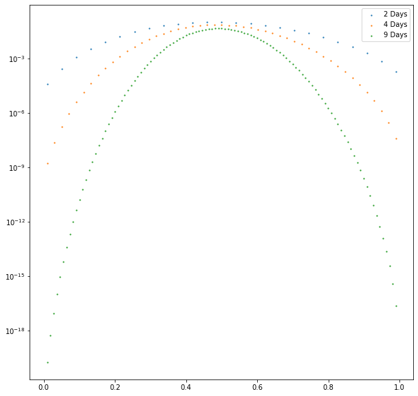

```python
fig,ax=plt.subplots(figsize=(10,10))
x1=np.linspace(0.01,0.99,len(conv_1))
a1=ax.scatter(x1,conv_1,label="2 Days",s=1.5)
x3=np.linspace(0.01,0.99,len(conv_3))
a3=ax.scatter(x3,conv_3,label="4 Days",s=1.5)
x8=np.linspace(0.01,0.99,len(conv_8))
a8=ax.scatter(x8,conv_8,label="9 Days",s=1.5)
ax.set_yscale("log")                            # Same thing on a log scale
plt.legend()
```

**B. Summed pdf after 5 days**

[figure not shown]

```python
fig,ax=plt.subplots()
x4=np.linspace(0.01,0.99,len(conv_4))
a5=ax.scatter(x4,conv_4,label="pdf summed over 5 days",s=1.5)
ax.set_title(" PDF after 5 days")
```

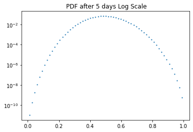

```python
fig,ax=plt.subplots()
x4=np.linspace(0.01,0.99,len(conv_4))
a5=ax.scatter(x4,conv_4,label="pdf summed over 5 days",s=1.5)
ax.set_title(" PDF after 5 days Log Scale")
ax.set_yscale("log")
```

This is not a gaussian since it is not a perfect parabola on a log scale. It looks very similar because of the Central Limit Theorem which states that when independent random variables are summed up, their properly normalized sum tends toward a normal distribution even if the original variables themselves are not normally distributed.

**Mathematical Explanation** Mathematically, the convolution independent Poisson distributions with mu=mu_n is still a Poisson distribution with mu=mu_1+mu_2+mu_3+....mu_n. This can be verified using the equations.  
**Conceptual Explanation** The distribution is discrete,unlike a gaussian. Summing discrete objects does not give a continuous output.

C.  
Probability distribution evolution on averaging days.

```python
# Rescaling
# First find the mu of the combined plot which is just the sum of components.
# Use stats.poisson.ppf to find the x values.
# Rescale the x axis by the number of convolutions.

a1=conv_1/2 # average of 2 days
a2=conv_2/3 # average of 3 days
a3=conv_3/4 # average of 4 days
a4=conv_4/5 # average of 5 days
a5=conv_5/6 # average of 6 days
a6=conv_6/7 # average of 7 days
a7=conv_7/8 # average of 8 days
a8=conv_8/9 # average of 9 days
```

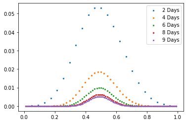

```python
fig,ax=plt.subplots()
x1=np.linspace(0.01,0.99,len(conv_1))
a1=ax.scatter(x,a1,label="2 Days",s=5)
x3=np.linspace(0.01,0.99,len(conv_3))
a3=ax.scatter(x3,a3,label="4 Days",s=5)
x5=np.linspace(0.01,0.99,len(conv_5))
a5=ax.scatter(x5,a5,label="6 Days",s=5)
x7=np.linspace(0.01,0.99,len(conv_7))
a7=ax.scatter(x7,a7,label="8 Days",s=5)
x8=np.linspace(0.01,0.99,len(conv_8))
a8=ax.scatter(x8,a8,label="9 Days",s=5)
plt.legend()
```

As the number of days increases, the height of the distribution decreases.

```python
#averaged of 5 days
#
```

**Problem 2**

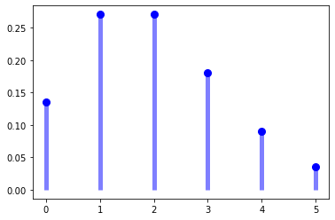

```python
from scipy.stats import rayleigh
import matplotlib.pyplot as plt
fig, ax = plt.subplots(1, 1)
mu = 2
mean, var, skew, kurt = poisson.stats(mu, moments='mvsk')
x = np.arange(poisson.ppf(0.01, mu),
              poisson.ppf(0.99, mu))
ax.plot(x, poisson.pmf(x, mu), 'bo', ms=8, label='poisson pmf')
ax.vlines(x, 0, poisson.pmf(x, mu), colors='b', lw=5, alpha=0.5)
```

```python
conv_1=np.convolve(p,p)
conv_2=np.convolve(conv_1,p)
conv_3=np.convolve(conv_2,p)
conv_4=np.convolve(conv_3,p)
conv_5=np.convolve(conv_4,p)
conv_6=np.convolve(conv_5,p)
conv_7=np.convolve(conv_6,p)
conv_8=np.convolve(conv_7,p)
```

**Problem 3**